# **Modul 3: Time Series Forecasting**

Manahan Siallagan - Muhammad Apriandito

### **Reading Material**

Please read the following materials.

1. [Forecasting: Principles and Practice](https://otexts.com/fpp2/)

### **Pretest**

Based on the reading materials, please answer the following questions and submit it via google classroom before the class starts.

1. What is Time Series forecasting?
2. Mention at least 2 algorithms that are commonly used for forecasting
3. Mention at least 3 evaluation metrics that can be used to measure the performance of the forecasting model

### **Case: Momoshop**

Momoshop is a shop that sells a variety of snacks. Momoshop management wants to predict how sales will be in 2021. The management provides monthly sales data since it first started operating in 2005.

#### **Time Series Forecasting**

Time series forecasting is a technique for the prediction of events through a sequence of time. The techniques predict future events by analyzing the trends of the past, on the assumption that future trends will hold similar to historical trends. In this case we will us time series forecasting to forecast Momoshop’s sales in 2021.

##### **Setup**

To do time series forecasting, we need to install and load the required packages.

```r
# Install package
install.packages(c("tidyverse",
  "lubridate",
  "readxl",
  "timetk",
  "tidymodels",
  "modeltime"))
```

```r
# Load package
library(tidyverse)
library(lubridate)
library(readxl)
library(timetk)
library(tidymodels)
library(modeltime)
```

##### **Load Data**

After the required packages are installed and loaded, we can directly load Momoshop sales data into the R environment.

```r
# Load Data
df <- read_csv2("data/momoshop-sales.csv")
```

```r
# Show data
df
```

| date | sales |
| --- | --- |
| 01/01/2005 | 8760 |
| 01/02/2005 | 8280 |
| 01/03/2005 | 8650 |
| 01/04/2005 | 8800 |
| 01/05/2005 | 9130 |
| 01/06/2005 | 9130 |
| 01/07/2005 | 9140 |
| 01/08/2005 | 9160 |
| 01/09/2005 | 9290 |
| 01/10/2005 | 9240 |

[output cut: 182 more lines]

It can be seen above, there are still errors in the data. The date variable should have the data type `date` not `character`. We can fix this using the `dmy()` function.

```r
# Fix Data
df_fix <- df %>%
  mutate(date = dmy(date))
```

##### **Visualize Data**

In the first stage, we can visualize Momoshop sales data to get basic insights such as trends, seasonality, and so on.

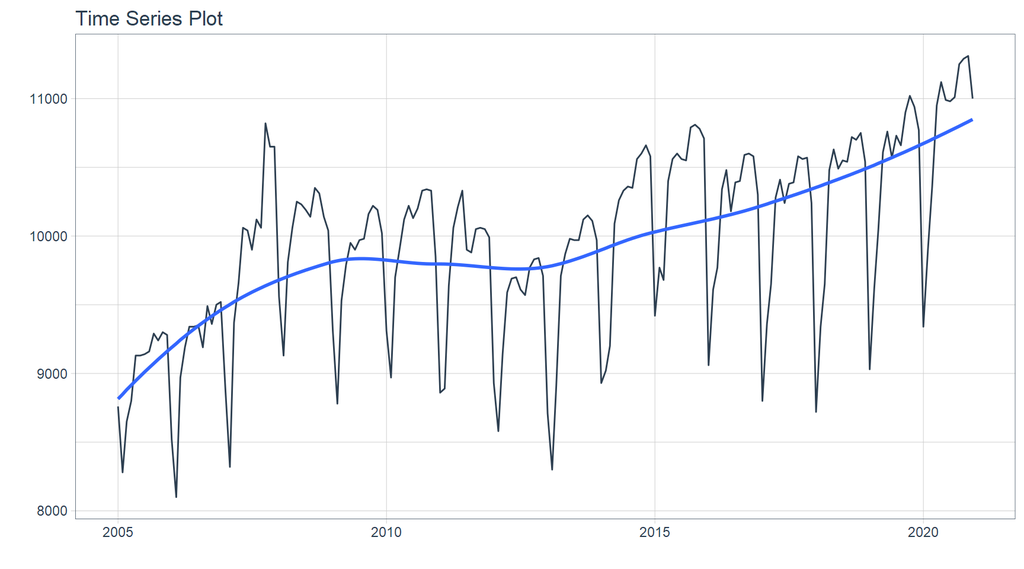

```r
# Visualize Data
df_fix %>%
  plot_time_series(date, sales, .interactive = FALSE)
```

##### Split Data

Before creating a forecast model, the data must first be split into training and testing. Training data is used to create models, while testing data is used to evaluate model performance.

```r
# Split data
splits <- df_fix %>%
  time_series_split(assess = "1 year", cumulative = TRUE)
```

```
## Using date_var: date
```

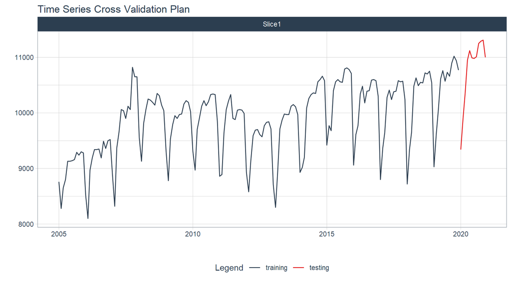

```r
# Visualize
splits %>%
  tk_time_series_cv_plan() %>%
  plot_time_series_cv_plan(date, sales, .interactive = FALSE)
```

##### Create & Fit Multiple Models

In R we get several forecasting models at once. In this case we will use 2 commonly used models for forecasting, namely ARIMA and ETS. we can set the model first.

```r
# Set ARIMA Model
model_fit_arima <- arima_reg() %>%
  set_engine("auto_arima") %>%
  fit(sales ~ date, training(splits))
```

```
## frequency = 12 observations per 1 year
```

```r
# Set ETS Model
model_fit_ets <- exp_smoothing() %>%
  set_engine(engine = "ets") %>%
  fit(sales ~ date, data = training(splits))
```

```
## frequency = 12 observations per 1 year
```

```r
# Add model to model table
model_table <- modeltime_table(
  model_fit_arima,
  model_fit_ets
)
```

##### **Calibrate the model to a testing set**

```r
calibration_table <- model_table %>%
  modeltime_calibrate(testing(splits))

calibration_table
```

| .model_id | .model | .model_desc | .type | .calibration_data |
| --- | --- | --- | --- | --- |
| 1 |  | ARIMA(2,0,0)(2,1,1)[12] | Test |  |
| 2 |  | ETS(M,A,M) | Test |  |

##### Testing Set Forecast & Accuracy Evaluation

Next, we can see the performance of our model using evaluation metrics such as mae, mape, rmse, etc. In addition, we can also use visualization to see the deviation of the predicted value from the actual value.

```r
# Menampilkan performa model
calibration_table %>%
  modeltime_accuracy() %>%
  table_modeltime_accuracy(.interactive = FALSE)
```

Accuracy Table

| .model_id | .model_desc | .type | mae | mape | mase | smape | rmse | rsq |
| --- | --- | --- | --- | --- | --- | --- | --- | --- |
| 1 | ARIMA(2,0,0)(2,1,1)[12] | Test | 244.04 | 2.24 | 1.05 | 2.26 | 254.33 | 0.99 |
| 2 | ETS(M,A,M) | Test | 93.02 | 0.85 | 0.40 | 0.86 | 108.30 | 0.99 |

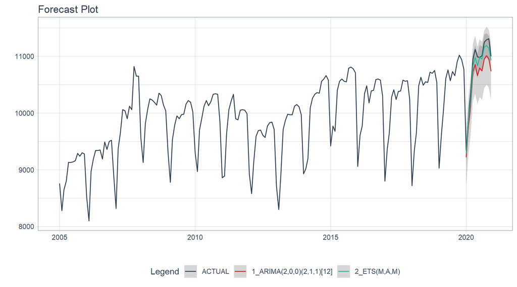

```r
# Memvisualisasikan hasil prediksi ke data test
calibration_table %>%
  modeltime_forecast(actual_data = df_fix) %>%
  plot_modeltime_forecast(.interactive = FALSE)
```

##### **Refit to Full Dataset & Forecast Forward**

The final stage is to refit the model with full data then forecast Momoshop sales in 2021.

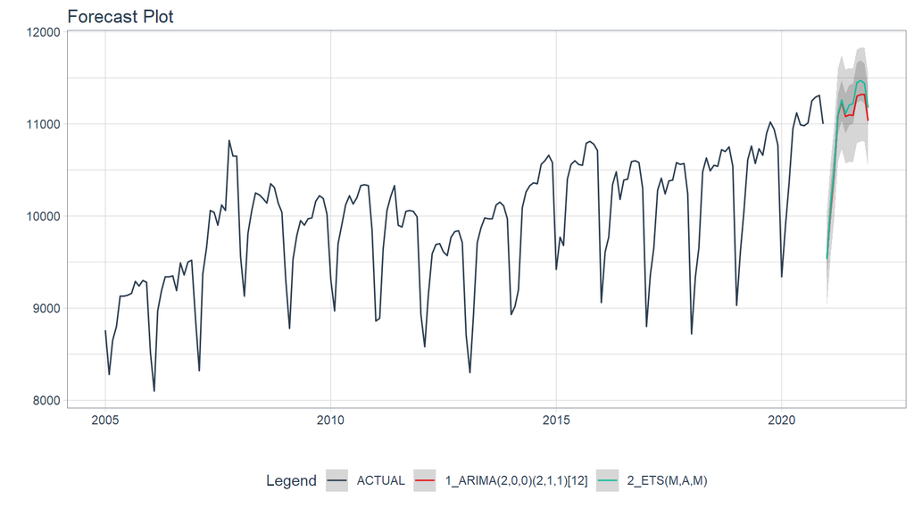

```r
calibration_table %>%
  modeltime_refit(df_fix) %>%
  modeltime_forecast(h = "12 months", actual_data = df_fix) %>%
  plot_modeltime_forecast(.interactive = FALSE)
```

### **Post Test**

1. Which model performs better at predicting Momoshop sales? why?
2. Interpret Momoshop’s forecasting sales results in 2021.
3. If you were a Momoshop management, what action would you take after seeing the sales forecast in 2021.